# IODS course project

#### 2.3.2. Multiple regression model of **point ~ attitude + stra**

Here I’m checking the linear regression of points ~ attitude and strategic learning approach outcome - I want to know if the strategic learning approach has a relationship to the exampoints of the students.

```r
# points ~ attitude + stra ----

att_st_lm <- lm(points ~ attitude + stra, data = lrn14_analysis)
att_st_lm_res <- summary(att_st_lm)
att_st_lm_res
```

```
##
## Call:
## lm(formula = points ~ attitude + stra, data = lrn14_analysis)
##
## Residuals:
##      Min       1Q   Median       3Q      Max
## -17.6482  -3.3135   0.5571   3.7966  10.9300
##
## Coefficients:
##             Estimate Std. Error t value Pr(>|t|)
## (Intercept)   8.9725     2.3966   3.744 0.000251 ***
## attitude      3.4664     0.5652   6.134 6.27e-09 ***
## stra          0.9132     0.5345   1.709 0.089438 .
## ---
## Signif. codes:  0 '***' 0.001 '**' 0.01 '*' 0.05 '.' 0.1 ' ' 1
##
## Residual standard error: 5.289 on 163 degrees of freedom
## Multiple R-squared:  0.2048, Adjusted R-squared:  0.195
## F-statistic: 20.99 on 2 and 163 DF,  p-value: 7.746e-09
```

```r
knitr::kable(att_st_lm_res$coefficients, digits=3, caption="Regression coefficients point ~ attitude + stra")
```

Regression coefficients point ~ attitude + stra

|  | Estimate | Std. Error | t value | Pr(>\|t\|) |
| --- | --- | --- | --- | --- |
| (Intercept) | 8.972 | 2.397 | 3.744 | 0.000 |
| attitude | 3.466 | 0.565 | 6.134 | 0.000 |
| stra | 0.913 | 0.534 | 1.709 | 0.089 |

Here the diagnostic plots of the regression model **points ~ attitude + stra**:

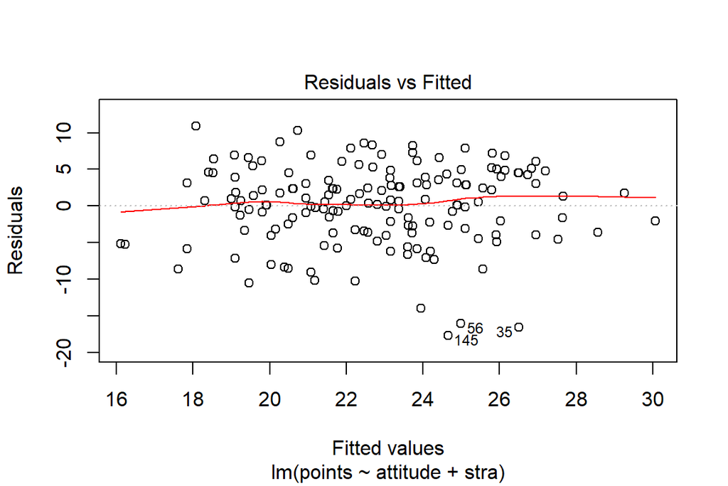

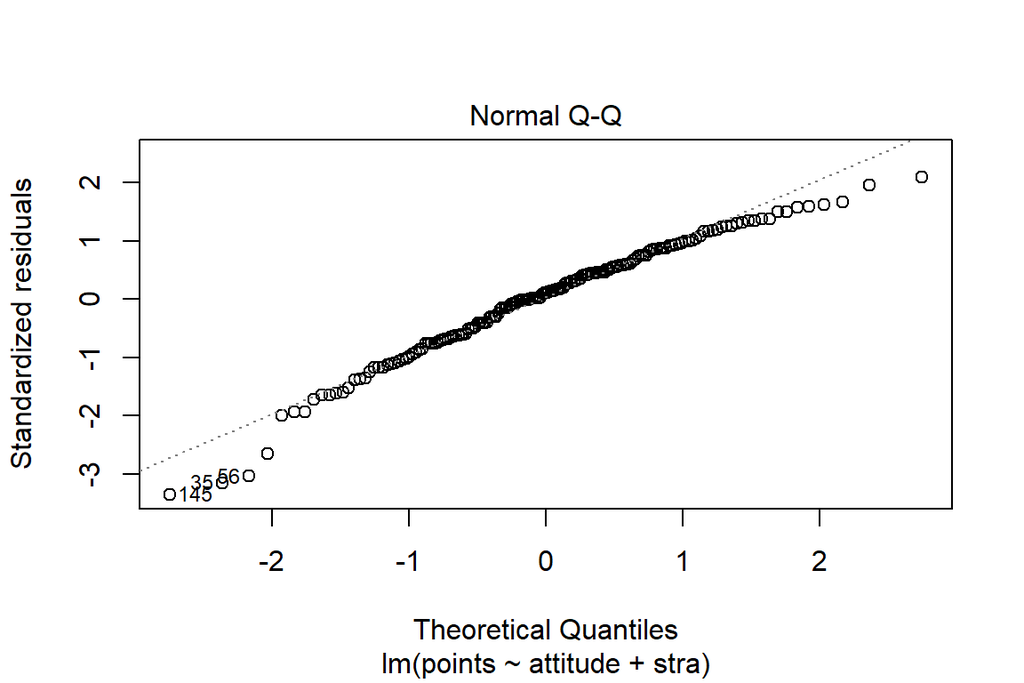

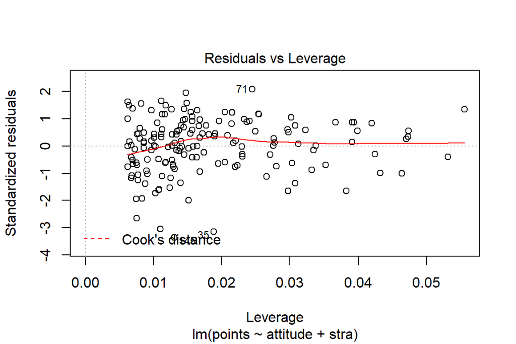

```r
plot(att_st_lm, which = c(1,2,5))
```

##### Regression model **point ~ attitude + stra** interpretation:

In this multiple regression I wanted to see if the strategic learning approach shows an influence on the amount of exampoints a student can reach. The outcome shows that the strategic learning approach has some influence but not a very strong one. Also the p-value of 0.08 shows that the significance of the influence is not very strong. The multiple R-squared is a bit higher compared to points ~ attitude regression model so we have a little higher correlations if we put the strategic learning approach into account.  
The diagnostic plots show more or less the same results as in the regression model point ~ attitude. Data is normal distributed and no outliers are significantly disturbing the analysis.

#### 2.3.3. Multiple regression model of **point ~ deep + surf + stra**

In the third regression model I put points vs. deep, surface and strategic learning approach into account. Does the combination of deep, surface and strategic learning approach have an influence in the exampoints of students.

```r
# points ~ + deep + surf + stra ----

de_su_st_lm <- lm(points ~ deep + surf + stra, data = lrn14_analysis)
de_su_st_lm_res <- summary(de_su_st_lm)

de_su_st_lm_res
```

```
##
## Call:
## lm(formula = points ~ deep + surf + stra, data = lrn14_analysis)
##
## Residuals:
##      Min       1Q   Median       3Q      Max
## -15.1208  -3.0725   0.5196   4.2798  10.3346
##
## Coefficients:
##             Estimate Std. Error t value Pr(>|t|)
## (Intercept)  26.9426     5.1147   5.268 4.34e-07 ***
## deep         -0.7472     0.8659  -0.863   0.3895
## surf         -1.6328     0.9149  -1.785   0.0762 .
## stra          0.9850     0.5962   1.652   0.1005
## ---
## Signif. codes:  0 '***' 0.001 '**' 0.01 '*' 0.05 '.' 0.1 ' ' 1
##
## Residual standard error: 5.827 on 162 degrees of freedom
## Multiple R-squared:  0.04072,    Adjusted R-squared:  0.02296
## F-statistic: 2.292 on 3 and 162 DF,  p-value: 0.0801
```

```r
knitr::kable(de_su_st_lm_res$coefficients, digits=3, caption="Regression coefficients point ~ deep + surf + stra")
```

Regression coefficients point ~ deep + surf + stra

|  | Estimate | Std. Error | t value | Pr(>\|t\|) |
| --- | --- | --- | --- | --- |
| (Intercept) | 26.943 | 5.115 | 5.268 | 0.000 |
| deep | -0.747 | 0.866 | -0.863 | 0.389 |
| surf | -1.633 | 0.915 | -1.785 | 0.076 |
| stra | 0.985 | 0.596 | 1.652 | 0.100 |

Here the diagnostic plots of the regression model **points ~ + deep + surf + stra**:

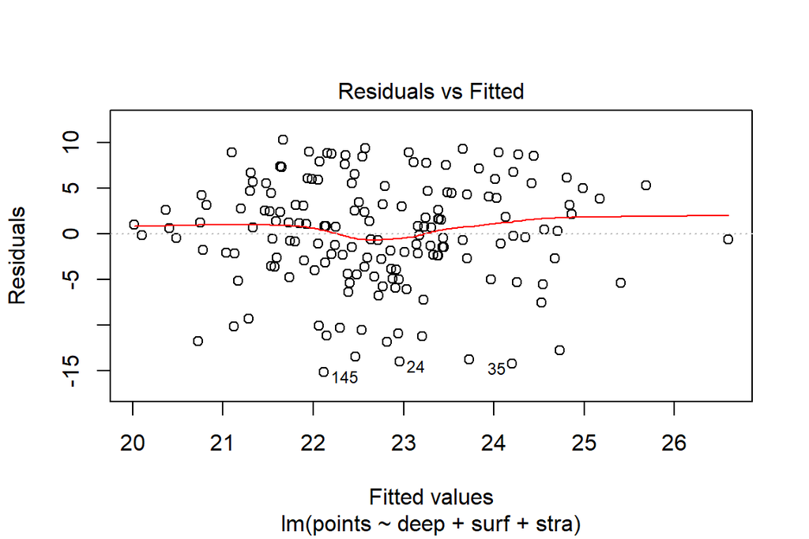

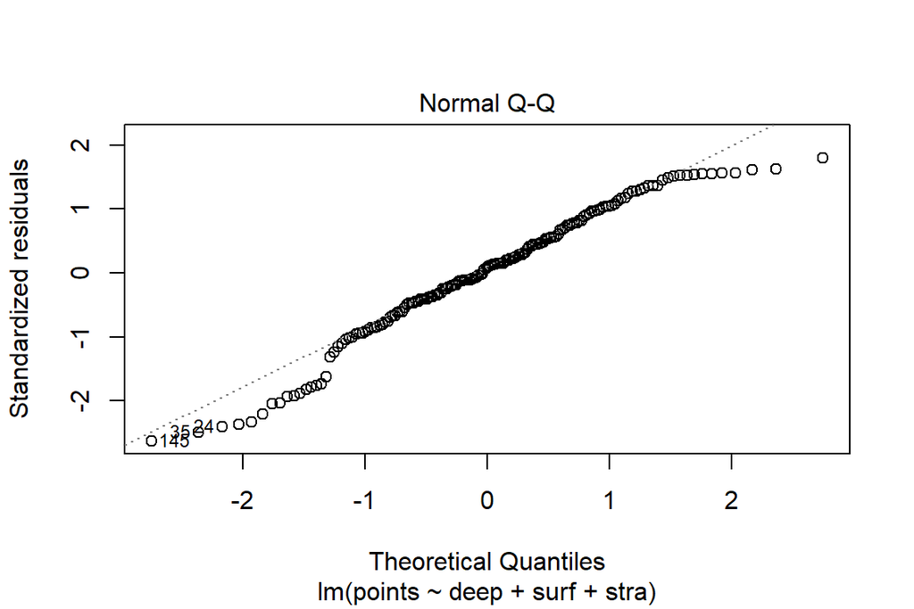

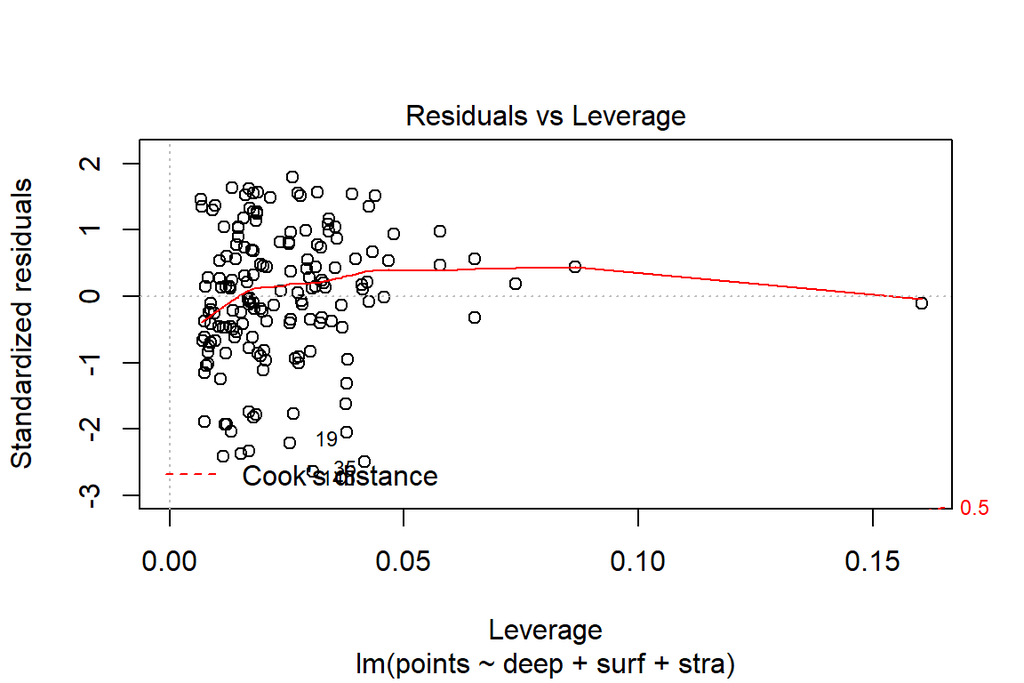

```r
plot(de_su_st_lm, which = c(1,2,5))
```

##### Regression model **point ~ deep + surf + stra** interpretation:

The outcome of this regression model shows that with a minor significance (0.0762) the surface learning approach has some indluence to the exam outcomes of students. Checking the estimate for surf show a negative value of -1.63 which means that students with a surface learning approach tent to have 1.6 points less as a test result with a increased surface learning approach value of 1. The deep learning approach seem to have no influence at all in the amount of points students reach at the exams and the stratetic approach has a non-significant positive influence.  
The multiple R-squared of 0.04 is very low and explains that there is more or less no correlation between these variables and the exampoints from the students.

Here I put the three variables into a `qplot()` to show the relationsships of the learning approaches and the exampoints.

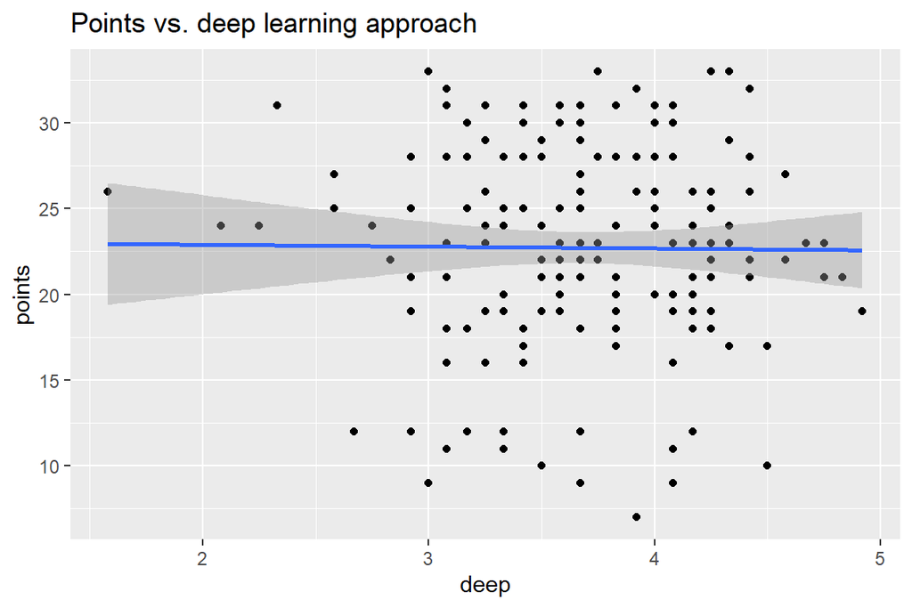

```r
library(ggplot2)
par(mfrow = c(2,2))
qplot(deep, points, data = lrn14_analysis) + geom_smooth(method = "lm") + ggtitle("Points vs. deep learning approach")
```

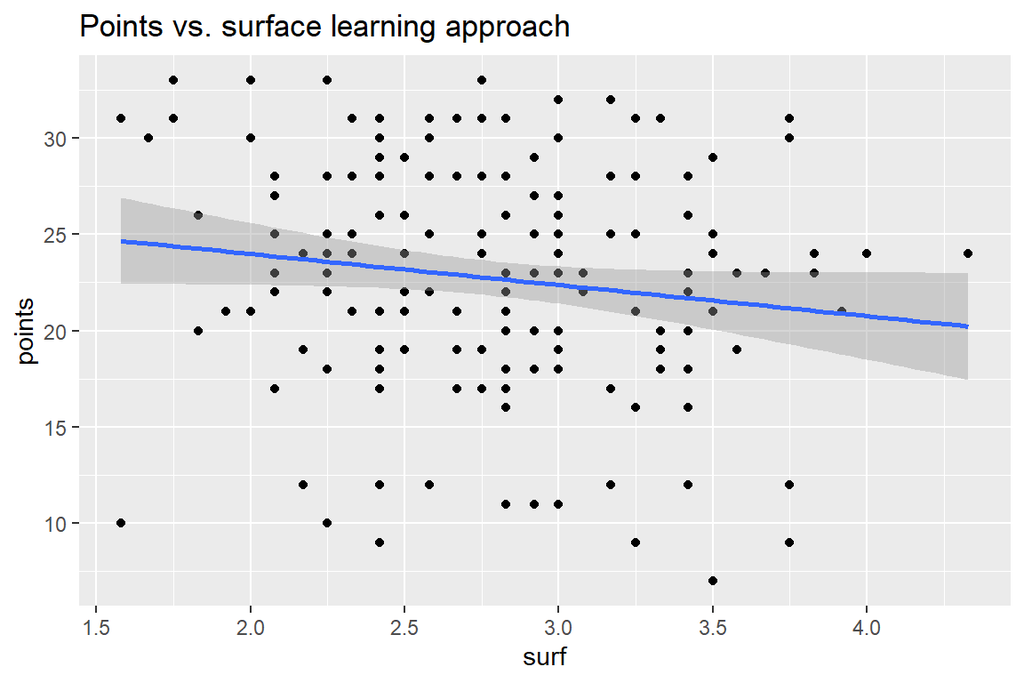

```r
qplot(surf, points, data = lrn14_analysis) + geom_smooth(method = "lm")+ ggtitle("Points vs. surface learning approach")
```

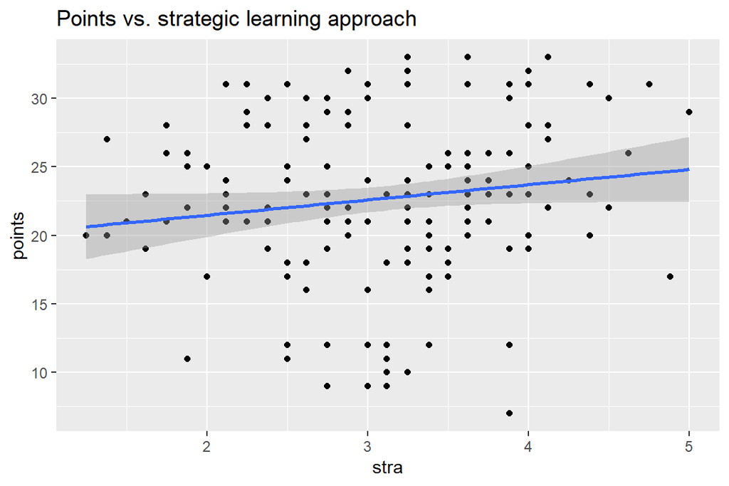

```r
qplot(stra, points, data = lrn14_analysis) + geom_smooth(method = "lm")+ ggtitle("Points vs. strategic learning approach")
```

So, this was a trial to analyse the dataset with simple and multiple regression models. I hope the interpretations are easily understood and the diary structure is not confusing you.  
I had fun preparing this first statistics and graph chapter and I’m looking forward to learn more…

# Chapter 3: Logistic regression

### Data wrangling and performing a logistic regression analysis

#### *Work of week 46 (11.11. - 17.11.2019)*

## 1. Data wrangling

R script is available on my github repository. To get to the script click [here](https://github.com/rikulampinen/IODS-project/blob/master/data/create_alc.R)

## 2. Analysis

## 2.1. Read the prepared data set

The working directory is set using `setwd()` and the data file “alc” prepared in the data wrangling part is read using `read.table()`function. Afterwards the data frame is checked.

```r
alc <- read.table(file =
       "C:/Users/richla/OneDrive/1 C - R-Folder/11-IODS-course/IODS-project/data/alc_table.txt", stringsAsFactors = TRUE)
       # read the data file and leave the binary values as they are

# Check the data frame
dim(alc)
```

```
## [1] 382  35
```

```r
str(alc)
```

```
## 'data.frame':    382 obs. of  35 variables:
##  $ school    : Factor w/ 2 levels "GP","MS": 1 1 1 1 1 1 1 1 1 1 ...
##  $ sex       : Factor w/ 2 levels "F","M": 1 1 1 1 1 2 2 1 2 2 ...
##  $ age       : int  18 17 15 15 16 16 16 17 15 15 ...
##  $ address   : Factor w/ 2 levels "R","U": 2 2 2 2 2 2 2 2 2 2 ...
##  $ famsize   : Factor w/ 2 levels "GT3","LE3": 1 1 2 1 1 2 2 1 2 1 ...
##  $ Pstatus   : Factor w/ 2 levels "A","T": 1 2 2 2 2 2 2 1 1 2 ...
##  $ Medu      : int  4 1 1 4 3 4 2 4 3 3 ...
##  $ Fedu      : int  4 1 1 2 3 3 2 4 2 4 ...
##  $ Mjob      : Factor w/ 5 levels "at_home","health",..: 1 1 1 2 3 4 3 3 4 3 ...
##  $ Fjob      : Factor w/ 5 levels "at_home","health",..: 5 3 3 4 3 3 3 5 3 3 ...
##  $ reason    : Factor w/ 4 levels "course","home",..: 1 1 3 2 2 4 2 2 2 2 ...
##  $ nursery   : Factor w/ 2 levels "no","yes": 2 1 2 2 2 2 2 2 2 2 ...
##  $ internet  : Factor w/ 2 levels "no","yes": 1 2 2 2 1 2 2 1 2 2 ...
##  $ guardian  : Factor w/ 3 levels "father","mother",..: 2 1 2 2 1 2 2 2 2 2 ...
```

[output cut: 21 more lines]

```r
colnames(alc)
```

```
##  [1] "school"     "sex"        "age"        "address"    "famsize"
##  [6] "Pstatus"    "Medu"       "Fedu"       "Mjob"       "Fjob"
## [11] "reason"     "nursery"    "internet"   "guardian"   "traveltime"
## [16] "studytime"  "failures"   "schoolsup"  "famsup"     "paid"
## [21] "activities" "higher"     "romantic"   "famrel"     "freetime"
## [26] "goout"      "Dalc"       "Walc"       "health"     "absences"
## [31] "G1"         "G2"         "G3"         "alc_use"    "high_use"
```

The data frame consists of 35 variables with 382 observations.

## 2.2. The data set

The provided data is from a approach on student achievement in secondary education in two Portugal schools.  
It was collected with school reports and questionaires and it includes:

- student grades
- demographic features
- social features
- school related features

The data consists of two data sets regarding the students’ performance in Mathematics (mat) and Portuguese language (por). In a publication by [Cortez & Silva, 2008](http://www3.dsi.uminho.pt/pcortez/student.pdf) this data was already used.

In the data wrangling part of this exercise the two data sets of mat and por were merged into one data set named “alc”. Columns (variables) which were not used in merging the data set were combined by averaging. Since we are interested to analyse the alcohol consumption of the students we created two new variables in the data set:

- “alc_use” –> calculated average of weekday (“Dalc”) and weekend (“Walc”) alcohol consumption
- “high_use” –> logical values created as TRUE or FALSE depending if the “alc_use” of a student is higher than 2

All other variables are explained in detail [here](https://archive.ics.uci.edu/ml/datasets/Student+Performance) (check attribute information).

## 2.3. Performing the analyses

## 2.3.1. Choose variables for the analyses

The task of this exercise is to figure out the relationships between high and low alcohol consumption and other variables in this data set. I have choosen to run the analyses on following four variables:

- sex –> student’s sex (binary: ‘F’ - female or ‘M’ - male)
- failures –> number of past class failures (numeric: n if 1<=n<3, else 4)
- famrel –> quality of family relationships (numeric: from 1 - very bad to 5 - excellent)
- absences –> number of school absences (numeric: from 0 to 93)

I have choosen these four variables for the data analyses for following reasons:

1. The student’s gender (“sex”) might have kind a great influence on the alcohol consumption. Young men tent to drink more alcohol for several reasons, women are able to control themselves (don’t take my steriotypical expressions serious please!).
2. The number of class failures (“failures”) of a student. Someone who fails in school more often might have a higher alcohol consumption then others (personal opionion) both as a causation of higher use or as a response to failure.
3. I think the overall quality of family relationships (“famrel”) might have a huge effect on a students alcohol consumption. I know, this is a very, very conservative point of view but in a country like Portugal (catholic, maybe more patriachic family structures) that might have an influence in young peoples alcohol consumption.
4. The number of school absences. I think if someone is absent from school they maybe spent their time also with drinking alcohol. I know there are other things to do as well, but when I was that age drinking beer was somehow a thing to spent your time.

## 2.3.2. Explore the distributions of the chosen variables numerically and graphically

The task is to explore the distribution of the variables I have choosen and the relationship with alcohol consumption numerically and graphically.

```r
library(tidyr)
library(dplyr)
library(ggplot2)
library(knitr)
library(kableExtra)
```

First I check how many female and male students are there:

```r
# check the number of female and male students
alc %>% group_by(sex) %>% summarise(count = n()) -> fm
knitr::kable(fm, caption="Students") %>% kable_styling(bootstrap_options = "hover", full_width = FALSE, position = "center")
```

Students

| sex | count |
| --- | --- |
| F | 198 |
| M | 184 |

### 2.3.2.1. General data overview

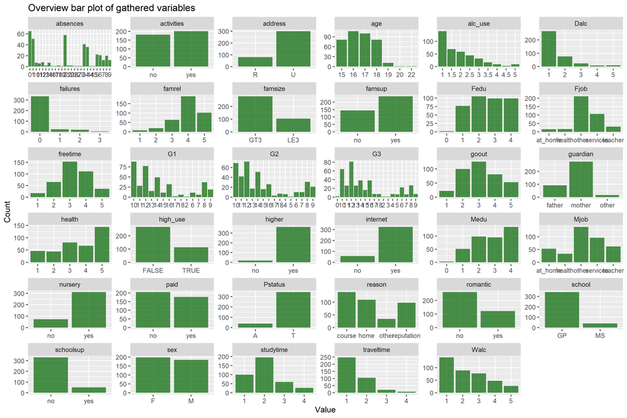

This bar plot gives us an overview over the different variables and might give a hint which variables have a strong relationship with alcohol consumption.

### 2.3.2.2. General alcohol consumption overview

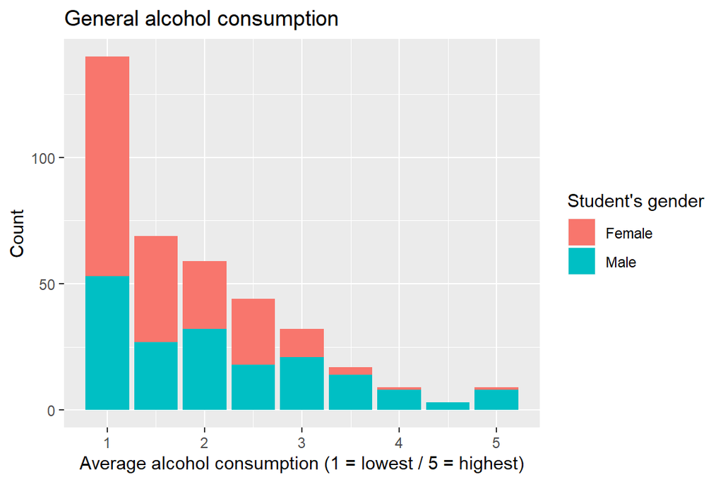

### 2.3.2.3. High alcohol consumption of students by gender

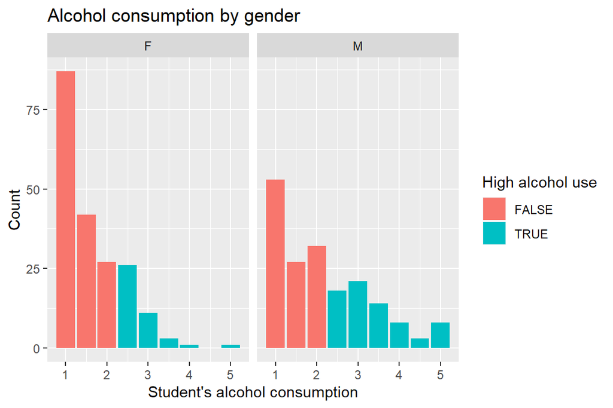

This graph gives an overview of the alcohol consumption of students devided by gender. With this graph you can see the amount of male or female students with higher alcohol consumption easier. High alcohol consumption (> 2) is indicated with turquise colour, lower alcohol consumption is indicated in red colour. You can see that the amount of male students with a high alcohol consumption is higher compared to female students.

### 2.3.2.4. High alcohol consumption and student’s class failures

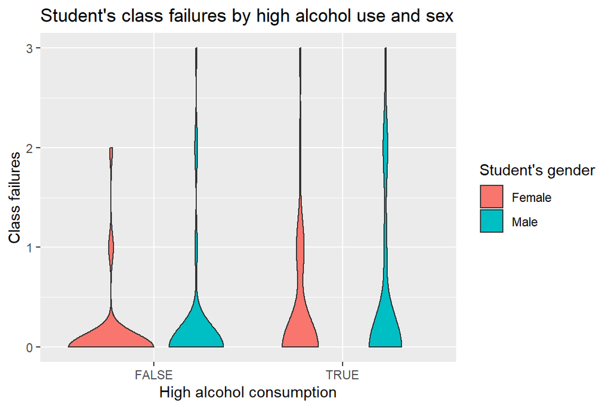

What is seen in this graph is that students with higher alcohol consumptuion tent to have a higher class failing rate. Female students with higher alcohol use have a higher count at 1 failure, male students have a higher count at 2 failures or 3 failures.

Generally, you see that students which have no high alcohol consumption fail less in classes.

### 2.3.2.5. High alcohol consumption and student’s family relationship status

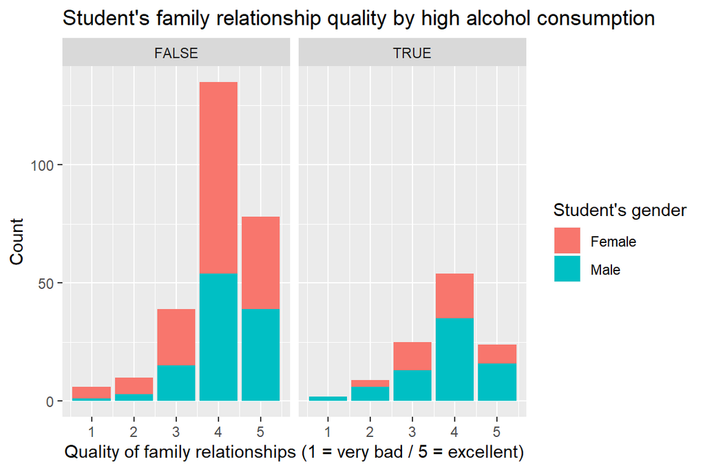

There are more students with a low alcohol conumption where the family relationship is good (4-5). Interestingly the amount of students with high alcohol consumption is also increasing with the quality of the family relationship status (higher count at status 3-5).

### 2.3.2.6. High alcohol consumption and student school abcences

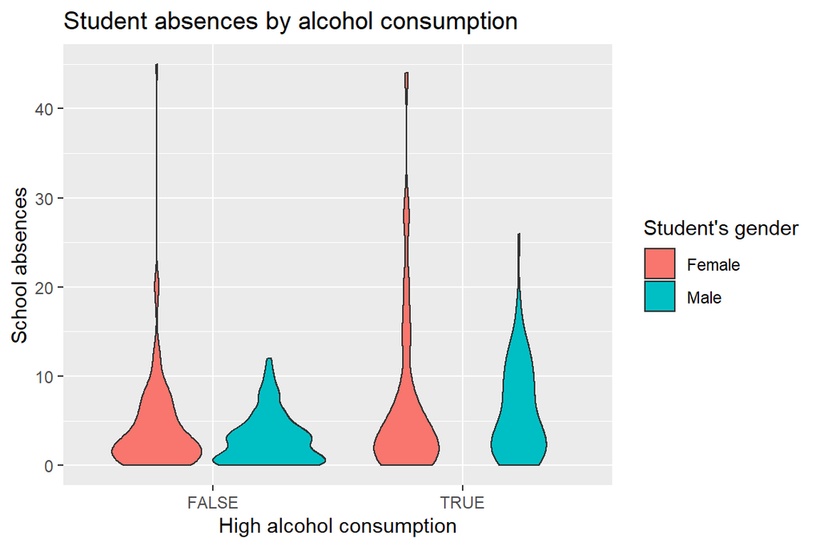

High alcohol use seems to have an influence on the rate of school absences. Students with a higher alcohol consumption have an increased absance amount. Females tent to be more absent than males, also if they don’t fall in the group of high alcohol consumers.

## 2.3.3. Logistic regression - explore the relationship between the choosen variables and the high alcohol consumption

### 2.3.3.1. Calculation of the logistic regression model

**I’m using in the model the four variables I have choosen: sex, failures, famrel and absences**

```r
# cv_glm, choosen variables logistic model
cv_glm <- glm(high_use ~ sex + failures + famrel + absences, data = alc, family = "binomial")

# Summary of the model (cv_glm_sum)
cv_glm_sum <- summary(cv_glm)
```

[output not shown]

Model coefficients of choosen variables

|  | Estimate | Std. Error | z value | Pr(>\|z\|) |
| --- | --- | --- | --- | --- |
| (Intercept) | -0.839 | 0.534 | -1.569 | 0.117 |
| sexM | 0.991 | 0.245 | 4.039 | 0.000 |
| failures | 0.425 | 0.189 | 2.252 | 0.024 |
| famrel | -0.276 | 0.128 | -2.153 | 0.031 |
| absences | 0.091 | 0.023 | 4.020 | 0.000 |

The model output shows nice results and also significant one. So which variables influance high alcohol consumption?

- Being a male student significantly (p = 5.37e-05 ***) increases the probability of high alcohol consumption by ~1.
- Class failure have a smaller probability but still have a positive effect on high consumption (p = 0.0243 *).
- The quality of family relationships has a negative effect on high alcohol consumption (p = 0.0314 *).
- School absences show also a significant positive effect on high alcohol consumption (5.83e-05 ***).

This is a first result. But we are not going to use these results as our final interpretation of the logistic regression. We are checking now the odds ratios of the model.

### 2.3.3.2. Calculating the odds ratios

Odds ratios and confidental intervals

|  | odds ratios | 2.5 % | 97.5 % |
| --- | --- | --- | --- |
| (Intercept) | 0.432 | 0.149 | 1.220 |
| sexM | 2.694 | 1.676 | 4.395 |
| failures | 1.529 | 1.057 | 2.228 |
| famrel | 0.759 | 0.589 | 0.976 |
| absences | 1.095 | 1.050 | 1.147 |

Interpretation of odds ratios: If the odds ratio is lower than 1 the risk of high alcohol consumption is lower, if it is greater than 1 the risk of high consumption increases. But we also have to have a look on the confidential interals - if the values cross the value of 1 the odds ratio cannot be significant! The odds ratios of this logistic model lead to following interpretation.

- **sexM** has a value of 2.7, the confidence interval is between 1.6 and 4.4. So this oods ratio tells us that the male students have a 2.7 times higher probability of consuming alcohol on a higher level.
- **failures** has a value of 1.5, the confidence interval is between 1.1 and 2.2. Failing in classes also increases the risk of high alcohol consumption by 1.5. So failing once increases the high alcohol consumption probability by 1.5.
- **famrel** has a value of 0.8, the confidence interval is between 0.6 and 1. It seems that the family relationships have a negative effect on high alcohol consumption.
- **absences** has a value of 1.095, the confidence interval is between 1.050 and 1.147. The amount of school absences increase the probability of higher alcohol consumption.

### 2.3.3.3. Explore the predictive power of the model

I calculated the probability of high alcohol use and added the data to the “alc” data frame. Then the prediction of a high alcohol consumption is defined to be a probability greater than 0.5 and also added this outcome to the “alc” data frame.  
Here are the last 20 data points with the probability and prediction outputs:

```
##     age Pstatus failures famrel high_use probability prediction
## 363  17       T        0      3    FALSE  0.28017549      FALSE
## 364  17       T        0      3    FALSE  0.29878836      FALSE
## 365  18       T        0      5    FALSE  0.09793643      FALSE
## 366  18       T        0      4    FALSE  0.15809170      FALSE
## 367  18       T        0      5     TRUE  0.11513474      FALSE
## 368  18       T        0      4    FALSE  0.12520393      FALSE
## 369  17       T        0      4     TRUE  0.33697399      FALSE
## 370  18       T        0      3     TRUE  0.42202546      FALSE
## 371  18       T        0      4    FALSE  0.31608605      FALSE
## 372  17       T        0      4    FALSE  0.33597108      FALSE
## 373  19       T        1      4    FALSE  0.37092103      FALSE
## 374  18       T        1      5     TRUE  0.45736187      FALSE
## 375  18       T        0      5    FALSE  0.10622930      FALSE
## 376  18       T        0      4    FALSE  0.19766624      FALSE
## 377  19       T        1      5    FALSE  0.16593043      FALSE
## 378  18       T        0      4    FALSE  0.14641340      FALSE
## 379  18       T        2      2    FALSE  0.41066768      FALSE
## 380  18       T        0      1    FALSE  0.30079024      FALSE
## 381  17       T        0      2     TRUE  0.49046497      FALSE
## 382  18       T        0      4     TRUE  0.31608605      FALSE
```

2 x 2 cross tabulation

|  | Prediction FALSE | Prediction TRUE |
| --- | --- | --- |
| **High use** |  |  |
| FALSE | 253 | 15 |
| TRUE | 82 | 32 |

Interpretation of the prediction:  
The 2 x 2 cross table gives us the results of the model prediction for high alcohol consumption compared to the real numbers.  
The model resulted in 253 correct false results and 82 false negative results. This means that the prediction fails to be correct. In 82 cases the model predicted that the student has no high alcohol consumption, but the student actually has high alcohol consumption. This false negative results should be much smaller.  
In 15 cases the model predicts high alcohol consumption but is wrong, that’s a false positive prediction. 253 cases were correctly predicted as false and 32 as true for high alcohol consumption.

### 2.3.3.4. Graphic visualization of actual values and predictions

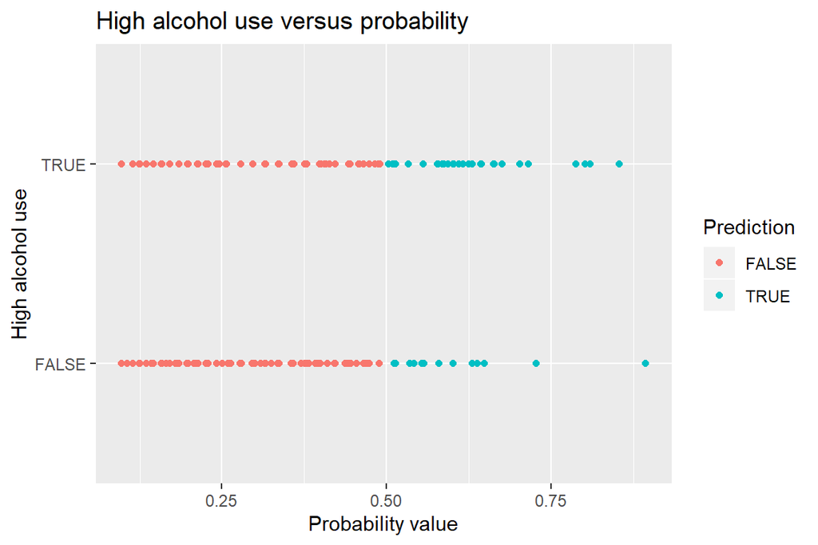

The graph represent the 2x2 cross table in a graphical view with the false negative values on top left of the graph. 82 cases predicted at FALSE but with a TRUE high alcohol use.

Target variable versus the predictions

|  | Prediction FALSE | Prediction TRUE | Prediction Sum |
| --- | --- | --- | --- |
| **high use** |  |  |  |
| FALSE | 0.6623 | 0.0393 | 0.7016 |
| TRUE | 0.2147 | 0.0838 | 0.2984 |
| Sum | 0.8770 | 0.1230 | 1.0000 |

Is the prediction of high alcohol use correct of not?  
This propability table gives us the correct predictions, false negative and false positive values as fractions of the total number. Results in fraction values between 0 and 1.  
So 21.5 % of are false negative predictions! 3.9 % are false positive predictions.

To measure the performance of of the logistic regression model we perform the loss function to calculate the average number of wrong predictions of our model.

This results to following value:

```
## [1] 0.2539267
```

So 25.4% of all predictions are wrong! Every fourth prediction is incorrect (to check that you can calculate the sum of false positive and false negative values from the Target variable versus the predictions table: 21.5 + 3.9 = 25.4).  
**So on the training data the model has a prediction error of 25.4 %.**

Here we are testing the how good our model is on unseen data. The loss function value is computed on a data which we did not use to to train the model. If the value is low it is good! We are performing the cross validation so that we test the logistic regression models on a defined set of observations. Here we choose the value of 10 - so the dataset will be split in 10 groups and 1 group of these 10 will be tested.

```r
# K-fold cross-validation
library(boot)
cross_val<- cv.glm(data = alc, cost = loss_func, glmfit = cv_glm, K = 10)
```

The cross validation results to following value:

```r
# average number of wrong predictions in the cross validation
cross_val$delta[1]
```

```
## [1] 0.2617801
```

This is the average number of wrong predictions in the cross validation. **The prediction error on the testing data is higher compared to the training data!**

Be aware of it that this value is changing with each new computing because the function computes everytime another set of observations with the logistic regression model.

The cross validation tells us if the model is too much in the data –> if the model is more generalized the value of cross validation shall be higher than the loss function value.

With the cross validation you check your model with the same data - the outcome should be higher number than the loss function –> that shows that the model is not too much in the data –> so the model is more kind of a general one!

## Bonus tasks

### Bonus task 1

The 10-fold cross-validation of my model was computed in section 2.3.3.6. above. My logistic model does not have a better performance compared to the DataCamp model (both have an error value of ~ 0.26).

I think a better model could be found - maybe more variables need to be used in the model, for example the age of the students or if students are in a relationship. These factors could make the model more accurate.

### Bonus task 2

#### Cross-validations with different logistic regression models

**Model 1: 8 variables (sex, age, Pstatus, guardian, failures, famrel, freetime, absences)**

**Model 2: 7 variables (sex, age, guardian, failures, famrel, freetime, absences) - Pstatus**

**Model 3: 6 variables (sex, age, failures, famrel, freetime, absences) - Pstatus, guardian**

**Model 4: 5 variables (sex, age, failures, freetime, absences) - Pstatus, guardian, famrel**

**Model 5: 4 variables (sex, age, failures, absences) - Pstatus, guardian, famrel, freetime**

**Model 6: 3 variables (sex, failures, absences) - Pstatus, guardian, famrel, freetime, age**

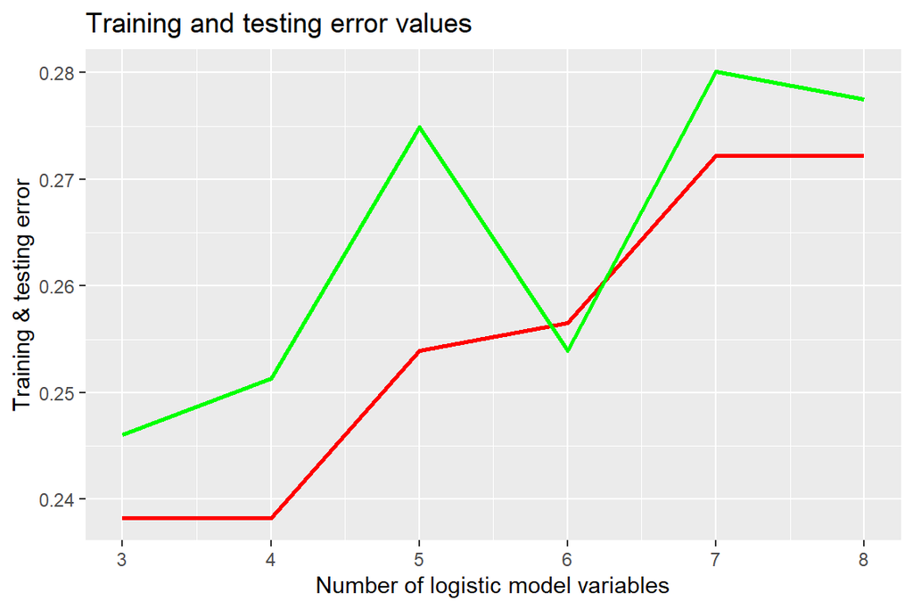

The graph shows a red line representing the training error values and a green line representing the testing error values. You can see how the error values are changing. As more variables are used for the logistic regression model as higher the training and testing error becomes. It seems the model is then too “deep” in the data.

# Chapter 4: Clustering and classification

### Data wrangling and performing clustering and classification

#### *Work of week 47 (18.11. - 24.11.2019)*

## 1. Analysis of Boston data set

## 1.1. Load the data set & check the structure

```r
# load necessary packages
library(MASS) # package includes the Boston data set
library(tidyr)
library(dplyr)
library(corrplot)
library(ggplot2)
library(GGally)
library(knitr)
library(kableExtra)

data(Boston) # load the Boston data set
```

## 1.2. The data set

The Boston data set consists of 14 variables with 506 observations. The data is bout housing values in Boston suburbs. The data set has following variables (columns):

- *crim*: the per capita crime rate by town
- *zn*: proportion of residential land zoned for lots over 25,000 sq.ft
- *indus*: proportion of non-retail business acres per town
- *chas*: Charles River dummy variable (= 1 if tract bounds river; 0 otherwise)
- *nox*: nitrogen oxides concentration (parts per 10 million)
- *rm*: average number of rooms per dwelling
- *age*: proportion of owner-occupied units built prior to 1940
- *dis*: weighted mean of distances to five Boston employment centres
- *rad*: index of accessibility to radial highways
- *tax*: full-value property-tax rate per $10,000
- *ptratio*: pupil-teacher ratio by town
- *black*: 1000(Bk - 0.63)^2 where Bk is the proportion of blacks by town
- *lstat*: lower status of the population (percent)
- *medv*: median value of owner-occupied homes in $1000s

We are interested in the later analysis on the per capita crime rate. Overall the crime rate is low and the data distribution is high on the low crime rate.

```r
str(Boston) # check the structure
```

```
## 'data.frame':    506 obs. of  14 variables:
##  $ crim   : num  0.00632 0.02731 0.02729 0.03237 0.06905 ...
##  $ zn     : num  18 0 0 0 0 0 12.5 12.5 12.5 12.5 ...
##  $ indus  : num  2.31 7.07 7.07 2.18 2.18 2.18 7.87 7.87 7.87 7.87 ...
##  $ chas   : int  0 0 0 0 0 0 0 0 0 0 ...
##  $ nox    : num  0.538 0.469 0.469 0.458 0.458 0.458 0.524 0.524 0.524 0.524 ...
##  $ rm     : num  6.58 6.42 7.18 7 7.15 ...
##  $ age    : num  65.2 78.9 61.1 45.8 54.2 58.7 66.6 96.1 100 85.9 ...
##  $ dis    : num  4.09 4.97 4.97 6.06 6.06 ...
##  $ rad    : int  1 2 2 3 3 3 5 5 5 5 ...
##  $ tax    : num  296 242 242 222 222 222 311 311 311 311 ...
##  $ ptratio: num  15.3 17.8 17.8 18.7 18.7 18.7 15.2 15.2 15.2 15.2 ...
##  $ black  : num  397 397 393 395 397 ...
##  $ lstat  : num  4.98 9.14 4.03 2.94 5.33 ...
##  $ medv   : num  24 21.6 34.7 33.4 36.2 28.7 22.9 27.1 16.5 18.9 ...
```

```r
knitr::kable(head(Boston)) %>%
  kable_styling(bootstrap_options = "striped", full_width = FALSE, position = "center") # the data frame head
```

| crim | zn | indus | chas | nox | rm | age | dis | rad | tax | ptratio | black | lstat | medv |
| --- | --- | --- | --- | --- | --- | --- | --- | --- | --- | --- | --- | --- | --- |
| 0.00632 | 18 | 2.31 | 0 | 0.538 | 6.575 | 65.2 | 4.0900 | 1 | 296 | 15.3 | 396.90 | 4.98 | 24.0 |
| 0.02731 | 0 | 7.07 | 0 | 0.469 | 6.421 | 78.9 | 4.9671 | 2 | 242 | 17.8 | 396.90 | 9.14 | 21.6 |
| 0.02729 | 0 | 7.07 | 0 | 0.469 | 7.185 | 61.1 | 4.9671 | 2 | 242 | 17.8 | 392.83 | 4.03 | 34.7 |
| 0.03237 | 0 | 2.18 | 0 | 0.458 | 6.998 | 45.8 | 6.0622 | 3 | 222 | 18.7 | 394.63 | 2.94 | 33.4 |
| 0.06905 | 0 | 2.18 | 0 | 0.458 | 7.147 | 54.2 | 6.0622 | 3 | 222 | 18.7 | 396.90 | 5.33 | 36.2 |
| 0.02985 | 0 | 2.18 | 0 | 0.458 | 6.430 | 58.7 | 6.0622 | 3 | 222 | 18.7 | 394.12 | 5.21 | 28.7 |

```r
knitr::kable(summary(Boston)) %>%
  kable_styling(bootstrap_options = "striped", position = "center", font_size = 11) %>%
  scroll_box(width = "100%", height = "300px")# summary statistics
```

|  | crim | zn | indus | chas | nox | rm | age | dis | rad | tax | ptratio | black | lstat | medv |
| --- | --- | --- | --- | --- | --- | --- | --- | --- | --- | --- | --- | --- | --- | --- |
|  | Min. : 0.00632 | Min. : 0.00 | Min. : 0.46 | Min. :0.00000 | Min. :0.3850 | Min. :3.561 | Min. : 2.90 | Min. : 1.130 | Min. : 1.000 | Min. :187.0 | Min. :12.60 | Min. : 0.32 | Min. : 1.73 | Min. : 5.00 |
|  | 1st Qu.: 0.08204 | 1st Qu.: 0.00 | 1st Qu.: 5.19 | 1st Qu.:0.00000 | 1st Qu.:0.4490 | 1st Qu.:5.886 | 1st Qu.: 45.02 | 1st Qu.: 2.100 | 1st Qu.: 4.000 | 1st Qu.:279.0 | 1st Qu.:17.40 | 1st Qu.:375.38 | 1st Qu.: 6.95 | 1st Qu.:17.02 |
|  | Median : 0.25651 | Median : 0.00 | Median : 9.69 | Median :0.00000 | Median :0.5380 | Median :6.208 | Median : 77.50 | Median : 3.207 | Median : 5.000 | Median :330.0 | Median :19.05 | Median :391.44 | Median :11.36 | Median :21.20 |
|  | Mean : 3.61352 | Mean : 11.36 | Mean :11.14 | Mean :0.06917 | Mean :0.5547 | Mean :6.285 | Mean : 68.57 | Mean : 3.795 | Mean : 9.549 | Mean :408.2 | Mean :18.46 | Mean :356.67 | Mean :12.65 | Mean :22.53 |
|  | 3rd Qu.: 3.67708 | 3rd Qu.: 12.50 | 3rd Qu.:18.10 | 3rd Qu.:0.00000 | 3rd Qu.:0.6240 | 3rd Qu.:6.623 | 3rd Qu.: 94.08 | 3rd Qu.: 5.188 | 3rd Qu.:24.000 | 3rd Qu.:666.0 | 3rd Qu.:20.20 | 3rd Qu.:396.23 | 3rd Qu.:16.95 | 3rd Qu.:25.00 |
|  | Max. :88.97620 | Max. :100.00 | Max. :27.74 | Max. :1.00000 | Max. :0.8710 | Max. :8.780 | Max. :100.00 | Max. :12.127 | Max. :24.000 | Max. :711.0 | Max. :22.00 | Max. :396.90 | Max. :37.97 | Max. :50.00 |

### 1.2.1 Overview plot and data description

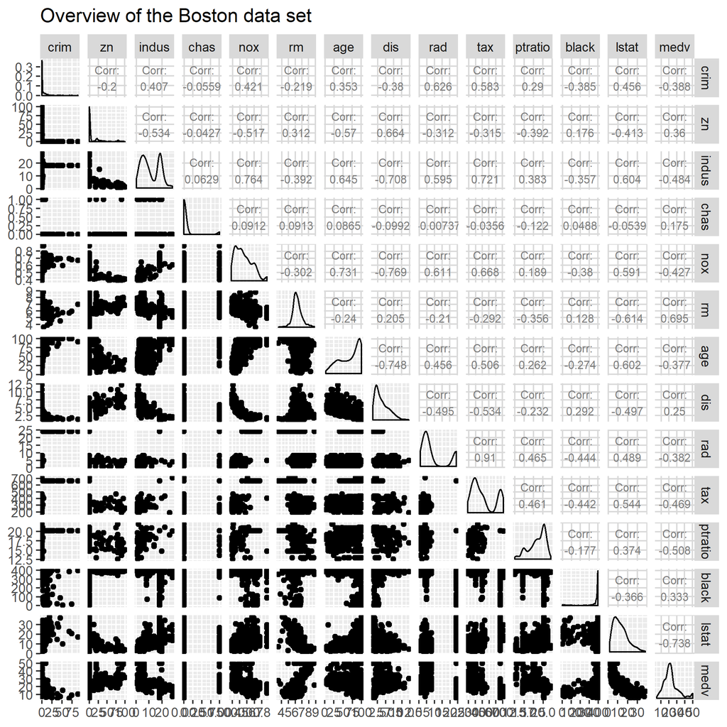

```r
# graphical overview of the Boston data set
ov_boston <- ggpairs(Boston, mapping = aes(), title ="Overview of the Boston data set",
                     lower = list(combo = wrap("facethist", bins = 20)),
                     upper = list(continuous = wrap("cor", size = 2.8)))
```

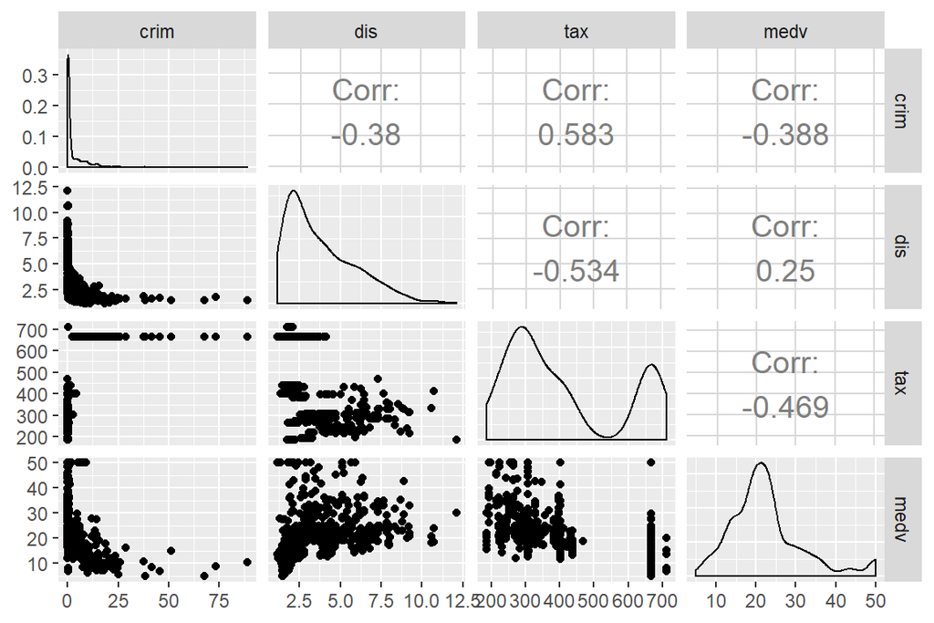

```r
# overview plot of interesting data
bos_detail <- Boston[,c("crim","dis","tax","medv")]

ov_bos_detail <- ggpairs(bos_detail, mapping = aes(),lower = list(combo = wrap("facethist", bins = 20)),
                     upper = list(continuous = wrap("cor", size = 5)))
ov_bos_detail
```

### 1.2.2. Data correlations of the Boston data set

```r
# calculate the correlation matrix and round it
cor_matrix<-cor(Boston) %>% round(digits = 2)

# print the correlation matrix
knitr::kable(cor_matrix, caption="Correlation matrix values") %>%
  kable_styling(bootstrap_options = "striped", full_width = FALSE, position = "center") %>%
  scroll_box(width = "100%", height = "300px")# summary statistics
```

Correlation matrix values

|  | crim | zn | indus | chas | nox | rm | age | dis | rad | tax | ptratio | black | lstat | medv |
| --- | --- | --- | --- | --- | --- | --- | --- | --- | --- | --- | --- | --- | --- | --- |
| crim | 1.00 | -0.20 | 0.41 | -0.06 | 0.42 | -0.22 | 0.35 | -0.38 | 0.63 | 0.58 | 0.29 | -0.39 | 0.46 | -0.39 |
| zn | -0.20 | 1.00 | -0.53 | -0.04 | -0.52 | 0.31 | -0.57 | 0.66 | -0.31 | -0.31 | -0.39 | 0.18 | -0.41 | 0.36 |
| indus | 0.41 | -0.53 | 1.00 | 0.06 | 0.76 | -0.39 | 0.64 | -0.71 | 0.60 | 0.72 | 0.38 | -0.36 | 0.60 | -0.48 |
| chas | -0.06 | -0.04 | 0.06 | 1.00 | 0.09 | 0.09 | 0.09 | -0.10 | -0.01 | -0.04 | -0.12 | 0.05 | -0.05 | 0.18 |
| nox | 0.42 | -0.52 | 0.76 | 0.09 | 1.00 | -0.30 | 0.73 | -0.77 | 0.61 | 0.67 | 0.19 | -0.38 | 0.59 | -0.43 |
| rm | -0.22 | 0.31 | -0.39 | 0.09 | -0.30 | 1.00 | -0.24 | 0.21 | -0.21 | -0.29 | -0.36 | 0.13 | -0.61 | 0.70 |
| age | 0.35 | -0.57 | 0.64 | 0.09 | 0.73 | -0.24 | 1.00 | -0.75 | 0.46 | 0.51 | 0.26 | -0.27 | 0.60 | -0.38 |
| dis | -0.38 | 0.66 | -0.71 | -0.10 | -0.77 | 0.21 | -0.75 | 1.00 | -0.49 | -0.53 | -0.23 | 0.29 | -0.50 | 0.25 |
| rad | 0.63 | -0.31 | 0.60 | -0.01 | 0.61 | -0.21 | 0.46 | -0.49 | 1.00 | 0.91 | 0.46 | -0.44 | 0.49 | -0.38 |
| tax | 0.58 | -0.31 | 0.72 | -0.04 | 0.67 | -0.29 | 0.51 | -0.53 | 0.91 | 1.00 | 0.46 | -0.44 | 0.54 | -0.47 |
| ptratio | 0.29 | -0.39 | 0.38 | -0.12 | 0.19 | -0.36 | 0.26 | -0.23 | 0.46 | 0.46 | 1.00 | -0.18 | 0.37 | -0.51 |
| black | -0.39 | 0.18 | -0.36 | 0.05 | -0.38 | 0.13 | -0.27 | 0.29 | -0.44 | -0.44 | -0.18 | 1.00 | -0.37 | 0.33 |
| lstat | 0.46 | -0.41 | 0.60 | -0.05 | 0.59 | -0.61 | 0.60 | -0.50 | 0.49 | 0.54 | 0.37 | -0.37 | 1.00 | -0.74 |
| medv | -0.39 | 0.36 | -0.48 | 0.18 | -0.43 | 0.70 | -0.38 | 0.25 | -0.38 | -0.47 | -0.51 | 0.33 | -0.74 | 1.00 |

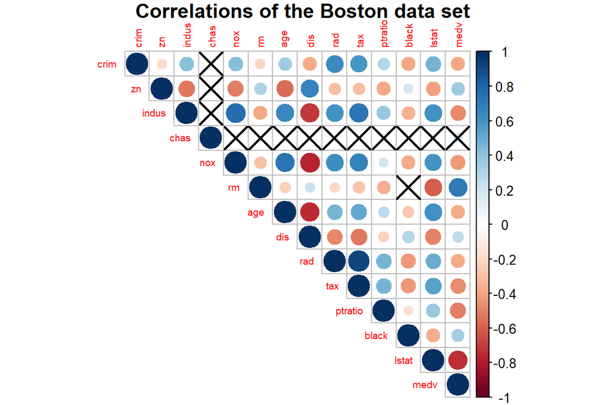

```r
# Specialized the insignificant value according to the significant level
p.mat <- cor.mtest(cor_matrix)$p

# visualize the correlation matrix
# correlations / colour shows the correlation values
corrplot(cor_matrix, method="circle", type="upper",  tl.cex = 0.6, p.mat = p.mat, sig.level = 0.01, title="Correlations of the Boston data set", mar=c(0,0,1,0))
```

Insignificant values are shown with a cross in the square. The crime rate shows rather strong positive correlation with accessibility to highways, the property-tax rate and with the lower population status.

## 1.3. Data set analysis

## 1.3.1. Data standardization (scaling of the data set)

Here we standardize the data set and print out summaries of the scaled data set. The data scaling is a method to standardize the values (some kind of transformation), so that we can compare the observations of the different variables. That creates negative and positive values with an overall mean of 0 and a standard deviation of 1.

```r
# center and standardize variables
boston_scaled <- scale(Boston)

# summaries of the scaled variables
knitr::kable(summary(boston_scaled), caption="Scaled Boston data set") %>%
  kable_styling(bootstrap_options = "striped", full_width = FALSE, position = "center", font_size = 11)  %>%
  scroll_box(width = "100%", height = "300px")
```

Scaled Boston data set

|  | crim | zn | indus | chas | nox | rm | age | dis | rad | tax | ptratio | black | lstat | medv |
| --- | --- | --- | --- | --- | --- | --- | --- | --- | --- | --- | --- | --- | --- | --- |
|  | Min. :-0.419367 | Min. :-0.48724 | Min. :-1.5563 | Min. :-0.2723 | Min. :-1.4644 | Min. :-3.8764 | Min. :-2.3331 | Min. :-1.2658 | Min. :-0.9819 | Min. :-1.3127 | Min. :-2.7047 | Min. :-3.9033 | Min. :-1.5296 | Min. :-1.9063 |
|  | 1st Qu.:-0.410563 | 1st Qu.:-0.48724 | 1st Qu.:-0.8668 | 1st Qu.:-0.2723 | 1st Qu.:-0.9121 | 1st Qu.:-0.5681 | 1st Qu.:-0.8366 | 1st Qu.:-0.8049 | 1st Qu.:-0.6373 | 1st Qu.:-0.7668 | 1st Qu.:-0.4876 | 1st Qu.: 0.2049 | 1st Qu.:-0.7986 | 1st Qu.:-0.5989 |
|  | Median :-0.390280 | Median :-0.48724 | Median :-0.2109 | Median :-0.2723 | Median :-0.1441 | Median :-0.1084 | Median : 0.3171 | Median :-0.2790 | Median :-0.5225 | Median :-0.4642 | Median : 0.2746 | Median : 0.3808 | Median :-0.1811 | Median :-0.1449 |
|  | Mean : 0.000000 | Mean : 0.00000 | Mean : 0.0000 | Mean : 0.0000 | Mean : 0.0000 | Mean : 0.0000 | Mean : 0.0000 | Mean : 0.0000 | Mean : 0.0000 | Mean : 0.0000 | Mean : 0.0000 | Mean : 0.0000 | Mean : 0.0000 | Mean : 0.0000 |
|  | 3rd Qu.: 0.007389 | 3rd Qu.: 0.04872 | 3rd Qu.: 1.0150 | 3rd Qu.:-0.2723 | 3rd Qu.: 0.5981 | 3rd Qu.: 0.4823 | 3rd Qu.: 0.9059 | 3rd Qu.: 0.6617 | 3rd Qu.: 1.6596 | 3rd Qu.: 1.5294 | 3rd Qu.: 0.8058 | 3rd Qu.: 0.4332 | 3rd Qu.: 0.6024 | 3rd Qu.: 0.2683 |
|  | Max. : 9.924110 | Max. : 3.80047 | Max. : 2.4202 | Max. : 3.6648 | Max. : 2.7296 | Max. : 3.5515 | Max. : 1.1164 | Max. : 3.9566 | Max. : 1.6596 | Max. : 1.7964 | Max. : 1.6372 | Max. : 0.4406 | Max. : 3.5453 | Max. : 2.9865 |

```r
# change the object to data frame
boston_scaled <- as.data.frame(boston_scaled)

knitr::kable(boston_scaled, caption="Scaled Boston data set") %>% kable_styling(bootstrap_options = "striped", full_width = FALSE, position = "center") %>% scroll_box(width = "100%", height = "300px")
```

Scaled Boston data set

[output not shown]

[output cut: 476 more lines]

## 1.3.2. Create a categorical variable (crime rate)

```r
# summary of the scaled crime rate
summary(boston_scaled$crim)
```

```
##      Min.   1st Qu.    Median      Mean   3rd Qu.      Max.
## -0.419367 -0.410563 -0.390280  0.000000  0.007389  9.924110
```

```r
# create a quantile vector of crim and print it
bins <- quantile(boston_scaled$crim)
knitr::kable(bins, caption="Quantiles of crim") %>% kable_styling(bootstrap_options = "striped", full_width = FALSE, position = "center")
```

Quantiles of crim

|  | x |
| --- | --- |
| 0% | -0.4193669 |
| 25% | -0.4105633 |
| 50% | -0.3902803 |
| 75% | 0.0073892 |
| 100% | 9.9241096 |

```r
# create a categorical variable 'crime'
crime <- cut(boston_scaled$crim, breaks = bins, include.lowest = TRUE, labels = c("low", "med_low", "med_high", "high"))

# look at the table of the new factor crime
knitr::kable(table(crime), caption="Categorical variables of crime") %>% kable_styling(bootstrap_options = "striped", full_width = FALSE, position = "center")
```

Categorical variables of crime

| crime | Freq |
| --- | --- |
| low | 127 |
| med_low | 126 |
| med_high | 126 |
| high | 127 |

```r
# remove original crim from the dataset
boston_scaled <- dplyr::select(boston_scaled, -crim)

# add the new categorical value to scaled data
boston_scaled <- data.frame(boston_scaled, crime)

knitr::kable(head(boston_scaled), caption = "Scaled Boston data set") %>%
  kable_styling(bootstrap_options = "striped", full_width = FALSE, position = "center",) %>%
  scroll_box(width = "100%", height = "100%") # the data frame head
```

Scaled Boston data set

| zn | indus | chas | nox | rm | age | dis | rad | tax | ptratio | black | lstat | medv | crime |
| --- | --- | --- | --- | --- | --- | --- | --- | --- | --- | --- | --- | --- | --- |
| 0.2845483 | -1.2866362 | -0.2723291 | -0.1440749 | 0.4132629 | -0.1198948 | 0.140075 | -0.9818712 | -0.6659492 | -1.4575580 | 0.4406159 | -1.0744990 | 0.1595278 | low |
| -0.4872402 | -0.5927944 | -0.2723291 | -0.7395304 | 0.1940824 | 0.3668034 | 0.556609 | -0.8670245 | -0.9863534 | -0.3027945 | 0.4406159 | -0.4919525 | -0.1014239 | low |
| -0.4872402 | -0.5927944 | -0.2723291 | -0.7395304 | 1.2814456 | -0.2655490 | 0.556609 | -0.8670245 | -0.9863534 | -0.3027945 | 0.3960351 | -1.2075324 | 1.3229375 | low |
| -0.4872402 | -1.3055857 | -0.2723291 | -0.8344581 | 1.0152978 | -0.8090878 | 1.076671 | -0.7521778 | -1.1050216 | 0.1129203 | 0.4157514 | -1.3601708 | 1.1815886 | low |
| -0.4872402 | -1.3055857 | -0.2723291 | -0.8344581 | 1.2273620 | -0.5106743 | 1.076671 | -0.7521778 | -1.1050216 | 0.1129203 | 0.4406159 | -1.0254866 | 1.4860323 | low |
| -0.4872402 | -1.3055857 | -0.2723291 | -0.8344581 | 0.2068916 | -0.3508100 | 1.076671 | -0.7521778 | -1.1050216 | 0.1129203 | 0.4101651 | -1.0422909 | 0.6705582 | low |

Quantiles 25% 75% of the data distribution quantiles give the values how many values are in which part of the data distribution median - the center of the quantiles (were the upper and lower 50 % quantiles meet)

## 1.3.3. Define training and test data set

```r
# number of rows in the Boston dataset
n_boston <- nrow(boston_scaled)

# choose randomly 80% of the rows
ind_boston <- sample(n_boston,  size = n_boston * 0.8)

# create train set (crime variable stays in the data set)
boston_train <- boston_scaled[ind_boston,]

# create test set
boston_test <- boston_scaled[-ind_boston,]

knitr::kable(head(boston_test), caption = "Test data set with Crime variable") %>%
  kable_styling(bootstrap_options = "striped", full_width = FALSE, position = "center",) %>%
  scroll_box(width = "100%", height = "100%") # the data frame head
```

Test data set with Crime variable

|  | zn | indus | chas | nox | rm | age | dis | rad | tax | ptratio | black | lstat | medv | crime |
| --- | --- | --- | --- | --- | --- | --- | --- | --- | --- | --- | --- | --- | --- | --- |
| 10 | 0.0487240 | -0.4761823 | -0.2723291 | -0.2648919 | -0.3994130 | 0.6154813 | 1.3283202 | -0.5224844 | -0.5769480 | -1.5037485 | 0.3289995 | 0.6227277 | -0.3949946 | med_low |
| 19 | -0.4872402 | -0.4368257 | -0.2723291 | -0.1440749 | -1.1793541 | -1.1359217 | 0.0006921 | -0.6373311 | -0.6006817 | 1.1753027 | -0.7413783 | -0.1348628 | -0.2536457 | med_high |
| 23 | -0.4872402 | -0.4368257 | -0.2723291 | -0.1440749 | -0.2030044 | 0.8215287 | 0.0863639 | -0.6373311 | -0.6006817 | 1.1753027 | 0.4406159 | 0.8495847 | -0.7972951 | med_high |
| 29 | -0.4872402 | -0.4368257 | -0.2723291 | -0.1440749 | 0.2994029 | 0.9174474 | 0.3132707 | -0.6373311 | -0.6006817 | 1.1753027 | 0.3424724 | 0.0205763 | -0.4493595 | med_high |
| 42 | -0.4872402 | -0.6161168 | -0.2723291 | -0.9207559 | 0.6907967 | -2.3331282 | 0.9145880 | -0.7521778 | -1.0397541 | -0.2566040 | 0.3147600 | -1.0941039 | 0.4422255 | med_low |
| 61 | 0.5846882 | -0.8755787 | -0.2723291 | -0.8776070 | -0.7737278 | -0.0843694 | 1.6290739 | -0.1779443 | -0.7371501 | 0.5748257 | 0.4210091 | 0.0695886 | -0.4167406 | med_low |

```r
# save the correct classes from test data
correct_classes <- boston_test$crime
correct_classes
```

```
##   [1] med_low  med_high med_high med_high med_low  med_low  low
##   [8] med_low  med_low  low      low      low      low      med_low
##  [15] med_low  med_low  low      med_low  med_high med_high med_high
##  [22] med_high high     med_high med_high med_high med_low  med_low
##  [29] med_low  med_low  med_low  med_low  med_low  low      low
##  [36] low      low      med_low  low      med_high med_high med_high
##  [43] med_low  med_low  med_low  med_low  med_high low      med_high
##  [50] med_high med_high low      med_low  low      low      med_low
##  [57] med_low  med_low  med_low  low      low      med_high med_high
##  [64] med_low  med_high low      low      low      low      low
##  [71] low      low      low      low      low      high     high
##  [78] high     high     high     high     high     high     high
##  [85] high     high     high     high     high     high     high
##  [92] high     high     high     high     high     high     high
##  [99] med_high med_low  low      low
## Levels: low med_low med_high high
```

```r
# remove the crime variable from test data set / so the prediction can be done later!
boston_test <- dplyr::select(boston_test, -crime)
knitr::kable(head(boston_test), caption = "Test data without Crime variable") %>%
  kable_styling(bootstrap_options = "striped", full_width = FALSE, position = "center",) %>%
  scroll_box(width = "100%", height = "100%") # the data frame head
```

Test data without Crime variable

|  | zn | indus | chas | nox | rm | age | dis | rad | tax | ptratio | black | lstat | medv |
| --- | --- | --- | --- | --- | --- | --- | --- | --- | --- | --- | --- | --- | --- |
| 10 | 0.0487240 | -0.4761823 | -0.2723291 | -0.2648919 | -0.3994130 | 0.6154813 | 1.3283202 | -0.5224844 | -0.5769480 | -1.5037485 | 0.3289995 | 0.6227277 | -0.3949946 |
| 19 | -0.4872402 | -0.4368257 | -0.2723291 | -0.1440749 | -1.1793541 | -1.1359217 | 0.0006921 | -0.6373311 | -0.6006817 | 1.1753027 | -0.7413783 | -0.1348628 | -0.2536457 |
| 23 | -0.4872402 | -0.4368257 | -0.2723291 | -0.1440749 | -0.2030044 | 0.8215287 | 0.0863639 | -0.6373311 | -0.6006817 | 1.1753027 | 0.4406159 | 0.8495847 | -0.7972951 |
| 29 | -0.4872402 | -0.4368257 | -0.2723291 | -0.1440749 | 0.2994029 | 0.9174474 | 0.3132707 | -0.6373311 | -0.6006817 | 1.1753027 | 0.3424724 | 0.0205763 | -0.4493595 |
| 42 | -0.4872402 | -0.6161168 | -0.2723291 | -0.9207559 | 0.6907967 | -2.3331282 | 0.9145880 | -0.7521778 | -1.0397541 | -0.2566040 | 0.3147600 | -1.0941039 | 0.4422255 |
| 61 | 0.5846882 | -0.8755787 | -0.2723291 | -0.8776070 | -0.7737278 | -0.0843694 | 1.6290739 | -0.1779443 | -0.7371501 | 0.5748257 | 0.4210091 | 0.0695886 | -0.4167406 |

## 1.3.4. Linear discriminant analysis of the training data set

```r
# linear discriminant analysis
lda.fit <- lda(crime ~ ., data = boston_train)

# print the lda.fit object
lda.fit
```

```
## Call:
## lda(crime ~ ., data = boston_train)
##
## Prior probabilities of groups:
##       low   med_low  med_high      high
## 0.2425743 0.2425743 0.2599010 0.2549505
##
## Group means:
##                  zn      indus        chas        nox          rm
## low       0.9673010 -0.9530721 -0.11163110 -0.8936426  0.48544204
## med_low  -0.1225658 -0.2564191  0.04906687 -0.5337363 -0.16888999
## med_high -0.3965857  0.1967388  0.21512144  0.3996019  0.06230297
## high     -0.4872402  1.0149946 -0.11943197  1.0468362 -0.39615191
##                 age        dis        rad        tax     ptratio
## low      -0.9275542  0.8925164 -0.6818635 -0.7448999 -0.49085598
## med_low  -0.2995881  0.3448273 -0.5470944 -0.4565240  0.05636051
## med_high  0.4251328 -0.3906981 -0.4131066 -0.3080232 -0.30147477
## high      0.8110436 -0.8580921  1.6596029  1.5294129  0.80577843
##               black       lstat        medv
## low       0.3797255 -0.79282816  0.59500204
## med_low   0.3089960 -0.08710789 -0.05094219
## med_high  0.1048290  0.02773812  0.15124361
## high     -0.9409716  0.88940638 -0.72382329
##
## Coefficients of linear discriminants:
##                 LD1          LD2         LD3
## zn       0.16410511  0.681866663 -0.85348753
## indus    0.04820604 -0.350014536  0.31884894
## chas    -0.07673945 -0.072161786  0.14211623
## nox      0.23634058 -0.768759427 -1.20176881
## rm      -0.09379994 -0.047499122 -0.12642164
## age      0.29622955 -0.353759758 -0.12504681
## dis     -0.17888648 -0.314799344  0.35147123
## rad      3.52623148  0.898183888 -0.27146138
## tax     -0.13376709  0.104435849  0.65817889
## ptratio  0.17523292 -0.069731792 -0.02021515
## black   -0.15795230  0.006573797  0.11652691
## lstat    0.16293576 -0.205310589  0.34402296
## medv     0.14031639 -0.372572031 -0.21838651
##
## Proportion of trace:
##    LD1    LD2    LD3
## 0.9513 0.0371 0.0117
```

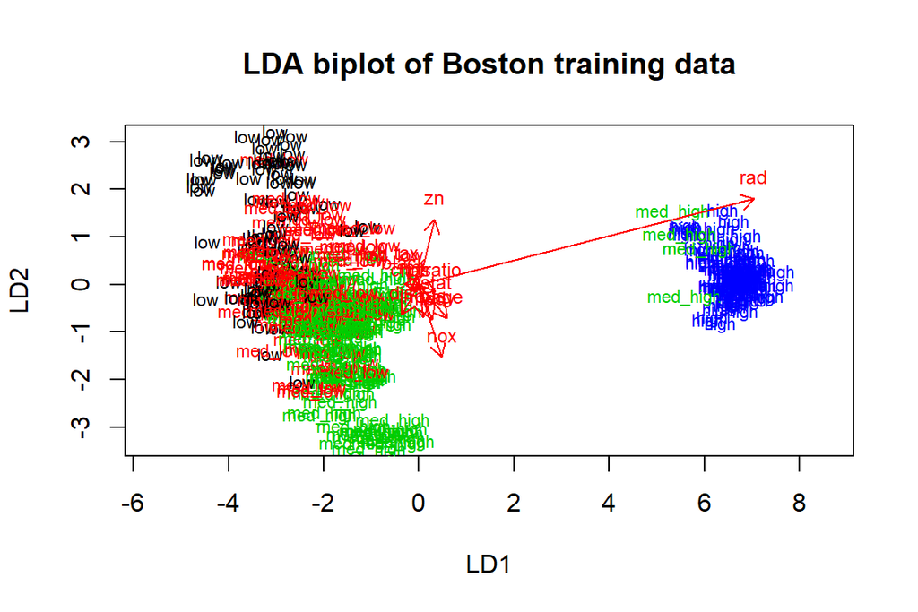

```r
# the function for lda biplot arrows
lda.arrows <- function(x, myscale = 1, arrow_heads = 0.1, color = "red", tex = 0.75, choices = c(1,2)){
  heads <- coef(x)
  arrows(x0 = 0, y0 = 0,
         x1 = myscale * heads[,choices[1]],
         y1 = myscale * heads[,choices[2]], col=color, length = arrow_heads)
  text(myscale * heads[,choices], labels = row.names(heads),
       cex = tex, col=color, pos=3)
}

# target classes as numeric
classes <- as.numeric(boston_train$crime)

# plot the lda results
plot(lda.fit, dimen = 2, col = classes, pch = classes, main = "LDA biplot of Boston training data")
lda.arrows(lda.fit, myscale = 2)
```

creates variable which characterize which variable discriminate most of the variables

classification –> you have the classes for the training data available e.g. logistic regression is a classification (0 or 1) - but just 2 groups

clustering –> you have training data which produces the clusters and these clusters can then be used for new data (data driven) it’s a descriptive method

trajectory analysis is clustering for example (data dependent)

propensity scores is another method for classification

## 1.3.5. Prediction of crime classes on the test data set

```r
# predict classes with test data
lda.pred <- predict(lda.fit, newdata = boston_test)
lda.pred$class
```

```
##   [1] med_low  med_low  med_low  med_high low      med_low  low
##   [8] med_low  med_low  low      low      med_low  low      med_low
##  [15] med_low  med_low  med_high med_high med_high med_high med_high
##  [22] med_high med_high med_high med_high med_high med_low  med_low
##  [29] med_low  med_high med_high low      low      low      low
##  [36] low      low      med_low  med_high med_high med_high med_low
##  [43] low      low      low      med_low  med_low  low      med_high
##  [50] med_high med_high low      low      low      low      med_low
##  [57] med_low  med_low  low      low      low      med_low  med_high
##  [64] med_low  med_low  med_low  low      low      med_low  med_low
##  [71] med_low  low      med_low  med_low  low      high     high
##  [78] high     high     high     high     high     high     high
##  [85] high     high     high     high     high     high     high
##  [92] high     high     high     high     high     high     high
##  [99] high     med_low  med_low  med_low
## Levels: low med_low med_high high
```

```r
# cross tabulate the results
pred_table <- table(correct = correct_classes, predicted = lda.pred$class)

knitr::kable(pred_table, align = "c",  caption="Pediction of test data" ) %>% kable_styling(bootstrap_options = "striped", full_width = F, position = "center") %>% add_header_above(c(" " = 1, "Predicted crime rate" = 4)) %>%  pack_rows("Correct rate", 1, 4)
```

Pediction of test data

|  | Predicted crime rate low | Predicted crime rate med_low | Predicted crime rate med_high | Predicted crime rate high |
| --- | --- | --- | --- | --- |
| **Correct rate** |  |  |  |  |
| low | 18 | 9 | 2 | 0 |
| med_low | 8 | 17 | 3 | 0 |
| med_high | 0 | 6 | 14 | 1 |
| high | 0 | 0 | 1 | 23 |

It seems that the prediction is quite good with the LDA.

## 1.3.5. Reload and standardize the Boston dataset and calculate the distances

```r
#load boston_scaled data set
data(Boston) # load the Boston data set

# scale the Boston data set again - named boston_scaled2
boston_scaled2 <- scale(Boston)
head(boston_scaled2)
```

```
##         crim         zn      indus       chas        nox        rm
## 1 -0.4193669  0.2845483 -1.2866362 -0.2723291 -0.1440749 0.4132629
## 2 -0.4169267 -0.4872402 -0.5927944 -0.2723291 -0.7395304 0.1940824
## 3 -0.4169290 -0.4872402 -0.5927944 -0.2723291 -0.7395304 1.2814456
## 4 -0.4163384 -0.4872402 -1.3055857 -0.2723291 -0.8344581 1.0152978
## 5 -0.4120741 -0.4872402 -1.3055857 -0.2723291 -0.8344581 1.2273620
## 6 -0.4166314 -0.4872402 -1.3055857 -0.2723291 -0.8344581 0.2068916
##          age      dis        rad        tax    ptratio     black
## 1 -0.1198948 0.140075 -0.9818712 -0.6659492 -1.4575580 0.4406159
## 2  0.3668034 0.556609 -0.8670245 -0.9863534 -0.3027945 0.4406159
## 3 -0.2655490 0.556609 -0.8670245 -0.9863534 -0.3027945 0.3960351
## 4 -0.8090878 1.076671 -0.7521778 -1.1050216  0.1129203 0.4157514
## 5 -0.5106743 1.076671 -0.7521778 -1.1050216  0.1129203 0.4406159
## 6 -0.3508100 1.076671 -0.7521778 -1.1050216  0.1129203 0.4101651
##        lstat       medv
## 1 -1.0744990  0.1595278
## 2 -0.4919525 -0.1014239
## 3 -1.2075324  1.3229375
## 4 -1.3601708  1.1815886
## 5 -1.0254866  1.4860323
## 6 -1.0422909  0.6705582
```

```r
# euclidean distance matrix
dist_eu <- dist(boston_scaled2)

# look at the summary of the distances
summary(dist_eu)
```

```
##    Min. 1st Qu.  Median    Mean 3rd Qu.    Max.
##  0.1343  3.4625  4.8241  4.9111  6.1863 14.3970
```

```r
# manhattan distance matrix
dist_man <- dist(boston_scaled2, method = "manhattan")

# look at the summary of the distances
summary(dist_man)
```

```
##    Min. 1st Qu.  Median    Mean 3rd Qu.    Max.
##  0.2662  8.4832 12.6090 13.5488 17.7568 48.8618
```

[figure not shown]

```r
# k-means clustering
km <-kmeans(boston_scaled2, centers = 3)

# plot the Boston dataset with clusters
pairs(boston_scaled2, col = km$cluster)
```